# Kolmogorov-Smirnov-test.R

Vinzent Aschir, Balaji Govindarajan and Ankit Kummar

2025-11-08

# empirical_CDF_and_Kolmogorov_Test

> **Instruction:** Study the empirical cumulative distribution function (ECDF) and the Kolmogorov–Smirnov test.Test whether a dataset follows a given distribution, or whether two samples come from the same one. Visualize ECDFs (implementated by yourself) and interpret.

for following the project on your own clone by:

```bash
git clone https://github.com/Aschir/empirical_CDF_and_Kolmogorov_Test/
```

## theory about Kolmogorov-Smirnov test (KS-Test)

### One-sample Kolmogorov-Smirnov Test

The one-sample Kolmogorov–Smirnov (KS) test quantifies the difference between the empirical distribution of a dataset and a theoretical distribution and can be applied when your analysed data is iid.

### Example:

Testing if $$X \sim N(\mu, \sigma^2) $$

$$training \sim Binom(n=1000, p=0.5)$$
with 100 performed trainings:

```r
set.seed(42)
# data
n = 1000
prob = 0.5
n_training = 100

X = rbinom(n_training, size = n, prob = prob)
```

$$H_0: X\sim N(\mu = 500,
\sigma^2)$$

$$H_1: X \not\sim N(\mu = 500,
\sigma^2)$$

Let’s have a look in it’s distribution:

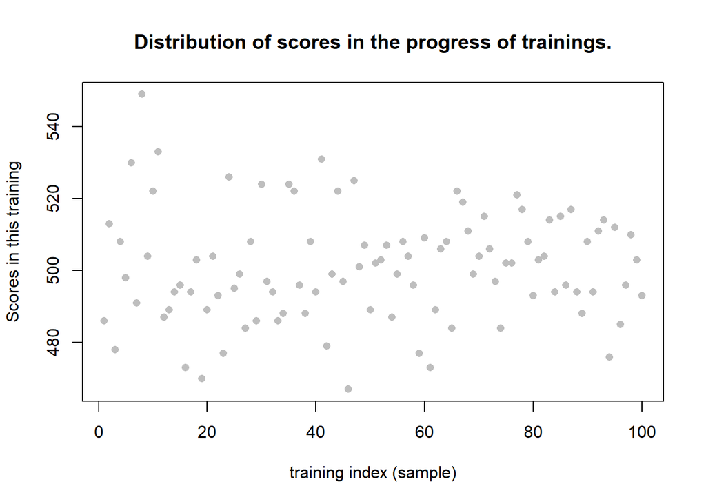

```r
set.seed(42)

# for visualisation:  10% quantile and closest point to 10% quantile
q10 <- quantile(X, 0.1)
closest_q10 <- X[which.min(abs(X - q10))]

# ---- Plot 1: the distribution of X ----
plot(1:length(X), X,
     xlab = "training index (sample)",
     ylab = "Scores in this training",
     main = "Distribution of scores in the progress of trainings.",
     pch = 16,
     col="grey")
```

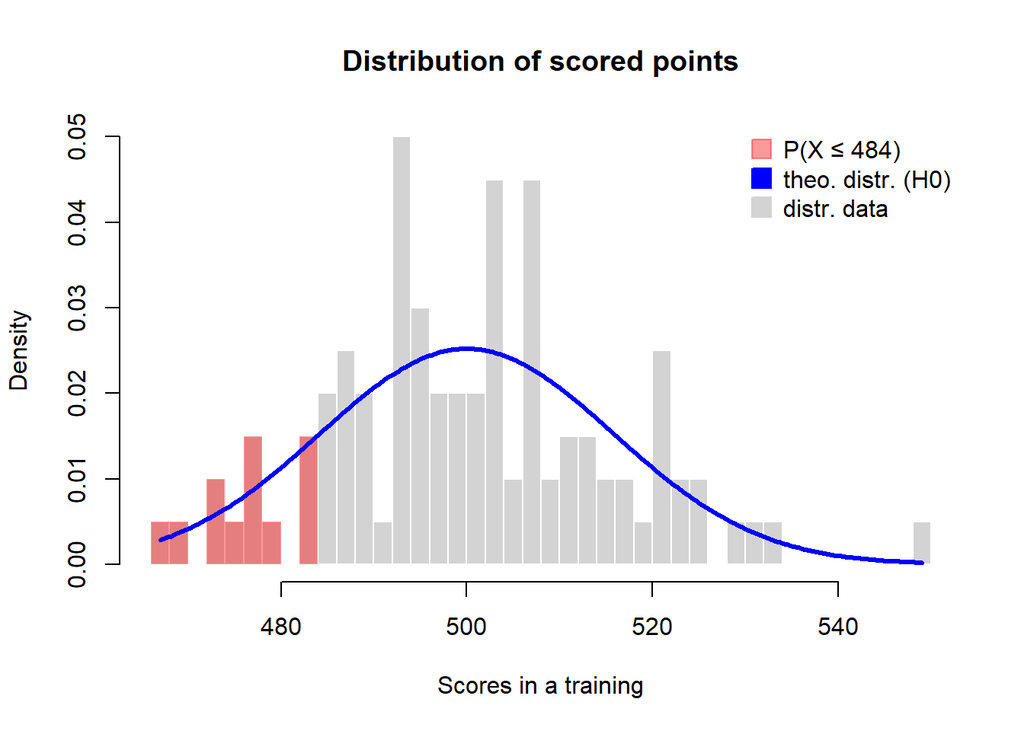

```r
# ---- Plot 2: Histogram + part shaded + theoretical curve ----
h = hist(X,
         breaks = 50,
         probability = TRUE,
         main = paste0("Distribution of scored points"),
         xlab = "Scores in a training",
         col = "lightgray",
         border = "white")

# --- Shade bars up to closest 10% quantile ---
for (i in 1:(length(h$breaks)-1)) {
  left  <- h$breaks[i]
  right <- h$breaks[i+1]
  mid   <- (left + right) / 2

  if (mid <= closest_q10) {
    rect(left, 0, right, h$density[i],
         col = rgb(1, 0, 0, 0.4),
         border = NA)
  }
}

# --- Theoretical distribution ---
x_vals <- seq(min(X), max(X), length.out = 200)
theo_density <- dnorm(x_vals, mean = 500, sd = sqrt(250))

lines(x_vals, theo_density, col = "blue", lwd = 3)

# --- Legend ---
legend(
  "topright",
  legend = c(paste0("P(X ≤ ", closest_q10, ")"),
             "theo. distr. (H0)",
             "distr. data"),
  pch    = 22,
  pt.cex = 2,
  pt.bg  = c(rgb(1,0,0,0.4), "blue", "lightgray"),  # fill colors
  col    = c(rgb(1,0,0,0.4), "blue", "lightgray"),  # border colors
  bty    = "n"
)
```

In a general setting,

Null hypothesis: $H_0: F_X = F_0$  
Alternative hypothesis: $H_1: F_X \neq F_0$

and our test statistic is:

$$D_n = \sup_x |F_n(x) - F(x)|$$

We Compute the CDF:

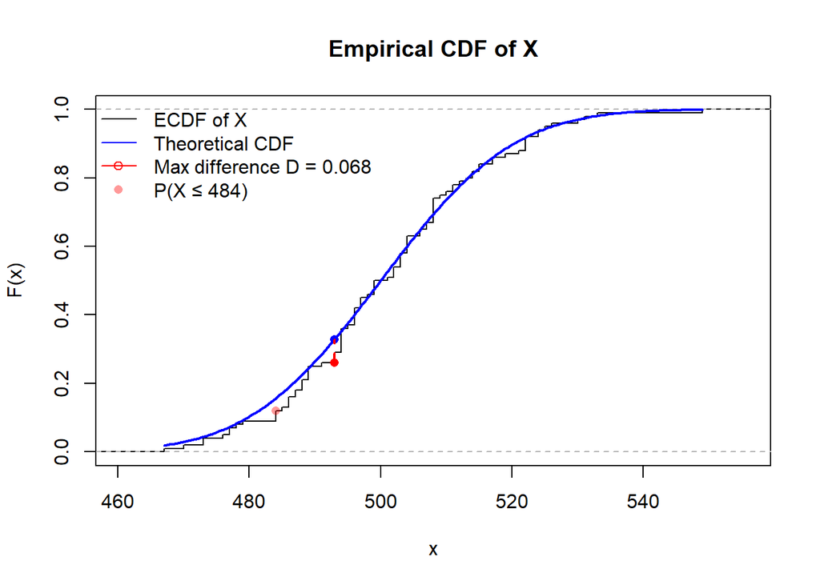

```r
set.seed(42)

#CDF (ECDF) of the given DATA.
  ecdf_X = ecdf(X) # we use the given func for the data

  plot(ecdf_X,
       main = "Empirical CDF of X",
       xlab = "x",
       ylab = "F(x)",
       verticals = TRUE,
       do.points = FALSE)

# theoretical cdf in manual computation of the cdf
  x_vals = seq(min(X), max(X), length.out = 200)
  cdf_theo <- pnorm(x_vals, mean = 500, sd = sqrt(250))

  lines(x_vals, cdf_theo, col = "blue", lwd = 2)

# Add the point seen in the previous data
  y_q10 <- ecdf_X(closest_q10)

  points(closest_q10, y_q10, col = rgb(1, 0, 0, 0.4), pch = 16)

# ---- Add vertical line for sup difference (Kolmogorov D) ----

  # max difference computation
  emp_vals <- ecdf_X(x_vals)
  diffs <- abs(emp_vals - cdf_theo)
  D <- max(diffs)


  x_value_f <- x_vals[which.max(diffs)]
  y_emp_at_f <- emp_vals[which.max(diffs)]
  y_theo_at_f <- cdf_theo[which.max(diffs)]
  eps <- 1e-8

  # draw the vertical line of max difference
  #segments(x0 = x_value_f, y0 = y_emp_at_f,
  #       x1 = x_value_f, y1 = y_theo_at_f,
  #       col = "red", lwd = 2, lty = 2)



  # mark max difference points in their distributions
  points(x_value_f, y_emp_at_f, col="red", pch=16)
  points(x_value_f, y_theo_at_f, col="blue", pch=16)
  lines(x = c(x_value_f-eps, x_value_f+eps), y = c(y_emp_at_f, y_theo_at_f),
      col = "red", lwd = 2, lty = 2)

  legend("topleft",
       legend = c("ECDF of X",
                  "Theoretical CDF",
                  paste0("Max difference D = ", round(D, 3)),
                  paste0("P(X ≤ ", closest_q10, ")")),
       col = c("black", "blue", "red", rgb(1,0,0,0.4)),
       lwd = c(1, 1, 1, NA),
       lty = c(1, 1, 1, NA),
       pch = c(NA, NA, 1, 16),
       bty = "n")
```

we used the maximum as a numerical approximation of the supremum.

the supremum would consider all points not only the ones in the dataset.

the maxium deviation difference is not normal distributed but follows a Kolmogorov-Smirnov deviations- distribution defined by:

The maximum deviation $D_n$ is **not normally distributed**. Instead, it follows the **Kolmogorov distribution**, which has the cumulative distribution function:

$$P(\sqrt{n} D_n \le \lambda) = 1 - 2 \sum_{k=1}^{\infty} (-1)^{k-1} e^{-2
k^2 \lambda^2}$$

which is in r:

```r
ks_pvalue <- function(D, n, maxK=1000){
  lambda <- sqrt(n) * D
  k <- 1:maxK
  pval <- 2 * sum((-1)^(k-1) * exp(-2 * k^2 * lambda^2))
  pval <- min(max(pval, 0), 1)
  return(pval)
}
```

now we compute the p-value: and form our decision boundary:

\[\text{p-value} = P(D_n \ge D_{\text{obs}} \mid H_0)\]

```r
p_value <- ks_pvalue(D, length(X))
p_value
```

```
## [1] 0.7431522
```

```r
# Decision based on alpha
alpha <- 0.05
if(p_value < alpha){
  cat("Reject H0: the data does not follow the theoretical distribution.\n")
} else {
  cat("Fail to reject H0: no evidence against the theoretical distribution.\n")
}
```

```
## Fail to reject H0: no evidence against the theoretical distribution.
```

we can compare our computation with the builtin-method:

```r
# Built-in KS test
ks_result <- ks.test(X, "pnorm", mean = 500, sd = sqrt(250))
ks_result
```

```
##
##  Asymptotic one-sample Kolmogorov-Smirnov test
##
## data:  X
## D = 0.068985, p-value = 0.7281
## alternative hypothesis: two-sided
```

# Vinzent explains until here but can also explain the following section if you want.

*Caracteristic:*

*explanation:* In practical it remains mostly unknown what the followed distribution of your data is. As Long as you can calculate an approximative ECDF, you can apply the test. # can also explain until here.

### Two-sample KS test (Ankit)

the two-sample KS-test test whether two samples are following the same theoretical distribution.

$X1 \sim K(\theta)$ and $X2 \sim K(\theta)$ ?

## theory: what is the Kolmogorov-Smirnov test?

use case:

1. the given data follows a distribution
2. two samples come from the same distribution

## Own implementation of Kolmogorov-Smirnov test

   (v): i would set the seed at the very beginning of the document once for the whole document if possible